# Understanding Isomorphism Theorems for Groups 群同构定理的理解

Algebra

If you struggle to have a clear mental picture of the isomorphism theorems, I hope this helps.

Author

Marcobisky

Published

March 31, 2025

**Prerequisites**: *Quotient group, kernel of a homomorphism, normal subgroup, basic category theory*.

Apologize for the handwriting, since it’s hard for quarto to support `tikz-cd` package.

## 1 Takeaways

- You gotta think of a homomorphism whenever there is a quotient.
- Homomorphisms are WAAAAY more important than groups themselves!
- **First isomorphism theorem**: Universal property of quotients, most important.
- **Second isomorphism theorem**: How subgroups behave under projections.
- **Third isomorphism theorem**: Just a diagram commutes.

## 2 Normal Subgroup $\iff$ Kernel

In this section, I will introduce to you a very important mathematical habit: always think of a homomorphism whenever there is a quotient. This helps me a lot in not only understanding the three isomorphism theorems, but also in various topics such as projective geometry, cohomology, etc. First, let’s look at some concepts, if you are familiar with them, you can skip this section.

### 2.1 Center and Centralizer

There are two very similar concepts: center of a group and conjugation operation. Center can be generalized to the concept of a centralizer. Conjugation is related to the concept of a normal subgroup and normalizer.

We know that not every group is abelian, but there are *some* elements in a group that commute with *every* other element in the group. We collect them to form a set. In fact, not only a set, but also a subgroup, called the **center** of the group.

**Center**

**Definition 1** The center $Z(G)$ of a group $G$ is:
$$\begin{aligned}
Z(G) :=& \{ z \in G \mid \forall g \in G, zg = gz \} \\
=& \{ z \in G \mid \forall g \in G, z = gzg^{-1} \}.
\end{aligned}$$

Here are some properties of the center, you can think about them yourself:

- $Z(G) \trianglelefteq G$. (See Definition 4 for the definition of normal subgroup.)
- $Z(G) = G$ iff $G$ is abelian.
- $Z(G)$ is itself abelian.

If we do not want to make it commutes with *every* element in the group, but only with some elements in a set $S$ (not necessarily a subgroup[^1] of $G$), this generalize to the definition of the **centralizer** of $S$ in $G$:

<sup>1</sup> $S \le G$ means $S$ is a subgroup of $G$. $S \subseteq G$ means $S$ is a subset of $G$.

**Centralizer**

**Definition 2** The **centralizer** $C_G(S)$ of a set $S$ $(S \subseteq G)$ of group $G$ is:
$$\begin{aligned}
C_G(S) :=& \{ c \in G \mid \forall s \in S, cs = sc \} \\
=& \{ c \in G \mid \forall s \in S, c = scs^{-1} \}.
\end{aligned}$$

**Proof: $C_G(S) \le G$**

1. **Closure**:

   Let $a, b \in C_G(S)$, i.e., $\forall s \in S, as = sa, bs = sb$. We want to show that $ab \in C_G(S)$:
   $$(ab)s = a(bs) = a(sb) = (as)b = (sa)b = s(ab) \implies ab \in C_G(S), \forall s \in S.$$
2. **Associativity**: Inherited from $G$.
3. **Identity**: $e_G \in C_G(S)$ because $\forall s \in S, es = se = s$.
4. **Inverse**: Let $a \in C_G(S)$, i.e., $\forall s \in S, as = sa$. We want to show that $a^{-1} \in C_G(S)$:
   $$\begin{aligned}
   as = sa & \implies a^{-1}as = a^{-1}sa \\
   & \implies s = a^{-1}sa \\
   & \implies sa^{-1} = a^{-1}saa^{-1} \\
   & \implies sa^{-1} = a^{-1}s \\
   & \implies a^{-1} \in C_G(S).
   \end{aligned}$$

Clearly, the center is a special case of the centralizer:
$$Z(G) = C_G(G).$$

### 2.2 Conjugation

The sandwich operation $gzg^{-1}$ in Definition 1 pops out frequenctly in math[^2]. We give it a name: **conjugation** of $z$ by $g$.

<sup>2</sup> Similar matrices, quarternion representation of 3D rotation, etc.

**Conjugation**

**Definition 3** $a, b \in G$ **conjugate** $:\iff$ $\exists g \in G$ such that $a = gbg^{-1}$.

It’s easy to show that conjugation defines an equivalence relation on $G$:

**Proof: Conjugation is an Equivalence Relation**

To show conjugation defined in Definition 3 is an equivalence relation $\sim$, we need to show it is reflexive, symmetric, and transitive.

1. Reflexive: $\exists e \in G, a = eae^{-1}$, hence $a \sim a$.
2. Symmetric:
   $$\begin{aligned}
   a \sim b & \iff \exists g \in G, a = gbg^{-1} \\
   & \iff \exists g^{-1} \in G, b = g^{-1}ag \\
   & \iff b \sim a.
   \end{aligned}$$
3. Transitive:
   $$\begin{aligned}
   a \sim b, b \sim c & \iff \exists g, h \in G, a = gbg^{-1}, b = hch^{-1} \\
   & \iff \exists g, h \in G, a = ghch^{-1}g^{-1} \\
   & \iff \exists gh \in G, a = (gh)c(gh)^{-1} \\
   & \iff a \sim c.
   \end{aligned}$$

### 2.3 A Natural Homomorphism

**Conjugation Homomorphism**

**Proposition 1** Let $G$ be a group and $f \in \operatorname{Hom}(G, \operatorname{Aut}(G))$, where $f(g)$ is defined by conjugation by $g$. Then
$$\ker f = Z(G).$$

**Proof of Proposition 1**

1. Conjugation by $g$ (denoted $\operatorname{conj}_g$) is in $\operatorname{Aut}(G)$.

   We need to check that $\operatorname{conj}_g$ gives an isomorphism from $G$ to itself.
   - **Claim**: $\forall g \in G, f(g) \in \operatorname{End}(G)$.

     $$f(g)(h h') = g(h h')g^{-1} = ghg^{-1}gh'g^{-1} = f(g)(h) f(g)(h').$$
   - **Claim**: $f(g)$ is bijective.

     $$f^{-1}(g) = f(g^{-1}).$$
2. $f$ is indeed a homomorphism.

   Take $\forall g, g' \in G$, then:
   $$\begin{aligned}
   f(g g')(h) &= gg'h(gg')^{-1} \\
   &= gg'hg'^{-1}g^{-1} \\
   &= f(g) \circ f(g')(h).
   \end{aligned}$$
3. $\ker f = Z(G)$.

   $$\begin{aligned}
   \ker f &= \{g \in G : \forall h \in G, ghg^{-1} = h\} \\
   &= \{g \in G : gh = hg \text{ for all } h \in G\} \\
   &= Z(G).
   \end{aligned}$$

**Inner and Outer Automorphisms**

**Proposition 2** Under the condition in Proposition 1,
$$\operatorname{im} f \triangleleft \operatorname{Aut}(G).$$

Define the **inner automorphism group** to be:
$$\operatorname{Inn}(G) := \operatorname{im} f,$$
and naturally the **Outer automorphism group** to be:
$$\operatorname{Out}(G) := \frac{\operatorname{Aut}(G)}{\operatorname{Inn}(G)}.$$
Then we have the following exact sequence:
$$1 \xrightarrow[]{} Z(G) \hookrightarrow G \xrightarrow[]{f} \operatorname{Aut}(G) \twoheadrightarrow \operatorname{Out}(G) \xrightarrow[]{} 1.$$

We omitted the proof, but visually,

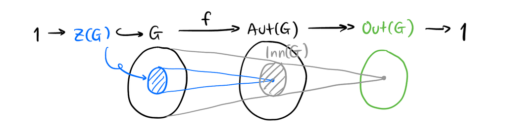

Figure 1: Relation between $Z(G)$, $\operatorname{Inn}(G)$, $\operatorname{Out}(G)$

### 2.4 Normal Subgroup and Normalizer

In fact, we could weaken the condition of $z = gzg^{-1}$ in Definition 1 and $c = scs^{-1}$ in Definition 2 to $N = gNg^{-1}$ and $S = gSg^{-1}$ to get the definition of a **normal subgroup** $N$ and a **normalizer** $N_G(S)$ respectively. This is different, because we no longer need *pointwise* commutativity but only commutativity *as a set*. In other words, the element after conjugation does not need to be exactly itself necessarily as long as it remains in some set.

**Normal Subgroup**

**Definition 4** A subgroup $N$ of a group $G$ is **normal** (denoted $N \trianglelefteq G$), iff $\forall g \in G, N = gNg^{-1}$, i.e.,
$$\forall g \in G, \exists n \in N, \forall m \in N, gmg^{-1} = n,$$
i.e., normal subgroups are invariant under any conjugation.

**Normalizer**

**Definition 5** The **normalizer** $N_G(S)$ of a set $S$ $(S \subseteq G)$ of group $G$ is:
$$\begin{aligned}
N_G(S) :=& \{ g \in G \mid gS = Sg \} \\
=& \{ g \in G \mid S = gSg^{-1} \}.
\end{aligned}$$

Their relationship is: If $S \trianglelefteq G$, then $N_G(S) = G$.

The following two results are important:

### 2.5 Kernels are normal

**Kernel of a homomorphism is normal**

**Lemma 1** Let $G, H$ be groups and $\varphi \in \operatorname{Hom}(G, H)$. Then $\ker(\varphi) \trianglelefteq G$, $\operatorname{im}(\varphi) \le H$.

**Proof: Kernel of a homomorphism is normal**

We just need to show that $\forall k \in \ker(\varphi)$, the conjugate of $k (gkg^{-1})$ is also in $\ker(\varphi)$, i.e.,
$$\varphi(gkg^{-1}) = e.$$
This is trivial.

### 2.6 Normal subgroups are kernels

**Every normal subgroup is the kernel of a homomorphism**

**Lemma 2** Let $N \trianglelefteq G$. Then $\exists \varphi \in \operatorname{Hom}(G, H)$ s.t. $N = \ker(\varphi)$.

HINT: Take $\varphi: G \to G/N$, the natural projection from $G$ to the group of cosets (called the quotient group $G/N$).

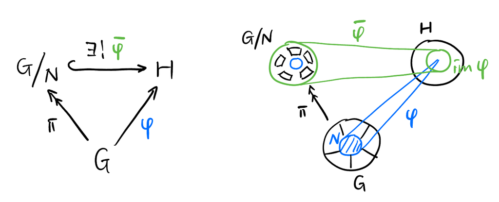

Figure 2: All homomorphisms factors uniquely through the quotient

As shown in Figure 2, any group homomorphism $\varphi: G \to H$ factors uniquely through the quotient group $G/N$, where $N = \ker(\varphi)$. The unique embedding $\bar{\varphi}$ implies the universal property of the quotient group (the pair $(G/N, \pi)$ could be viewed as a **initial object** of a **coslice category**[^3]).

<sup>3</sup> A coslice category is the dual of a slice category, which is a special case of a [comma category](https://en.wikipedia.org/wiki/Comma_category#Coslice_category).

So we have establish the fact that quotients and group homomorphisms are equivalent!

## 3 Isomorphism Theorem I

Figure 2 could be viewed as part of the **canonical decomposition** of a group homomorphism:

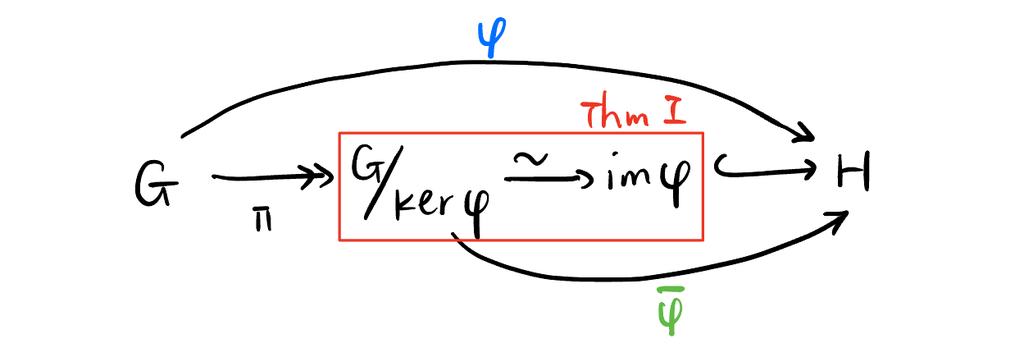

Figure 3: The red box in the canonical decomposition is exactly the first isomorphism theorem

The red box in Figure 3 is exactly the first isomorphism theorem:

**First Isomorphism Theorem**

**Theorem 1** Let $G$ and $H$ be groups and let $\varphi: G \to H$ be a homomorphism. Then:
$$G/\ker(\varphi) \simeq \operatorname{im}(\varphi)$$

The rest of the isomorphism theorems largely relies on this first theorem.

## 4 Isomorphism Theorem II

**Some lemmas**

**Lemma 3** Let $G$ be a group and $N \trianglelefteq G$, $S \le G$. Then:
$$N \trianglelefteq SN \le G \ge S \trianglerighteq S \cap N.$$

**Proof**

1. $SN \le G$:
   - **Nonempty**: Trivial.
   - **Closure**: Let $s_1n_1, s_2n_2 \in SN$, we want to show that $(s_1n_1)(s_2n_2) \in SN$:
     $$(s_1n_1)(s_2n_2) = s_1(n_1s_2)n_2.$$
     How to deal with the middle term? Since $N \trianglelefteq G$, we have $n_1s_2 = sn_1$ for some $s \in N$. Then:
     $$s_1(n_1s_2)n_2 = s_1(sn_1)n_2 = (s_1s)(n_1n_2) \in SN.$$
   - **Inverses**: Let $sn \in SN$, we want to show that $(sn)^{-1} = n^{-1}s^{-1} \in SN$. Again use the fact that $N \trianglelefteq G$:
     $$\exists s' \in N, n^{-1}s^{-1} = s'n^{-1} \in SN.$$
2. The rest can be proved by this diagram:

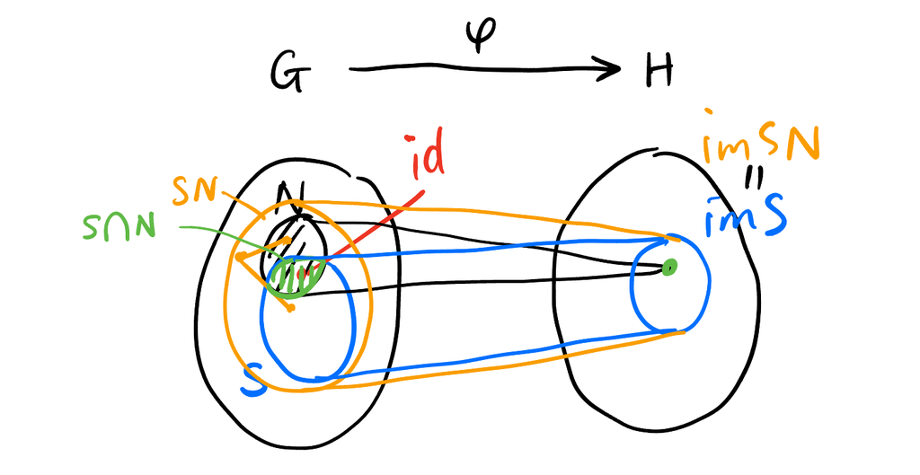

   Figure 4: Proof of the isomorphism theorem 2

**Second Isomorphism Theorem**

**Theorem 2** Let $G$ be a group and $N \trianglelefteq G$, $S \le G$. Then:
$$\frac{SN}{N} \simeq \frac{S}{S \cap N}$$

**Proof**

As shown in Figure 4, we have:

- $N \trianglelefteq SN$, since $N = \ker(\varphi|_{SN})$. By the first isomorphism theorem, we have $\frac{SN}{N} \simeq \varphi (SN)$.
- $S \cap N \trianglelefteq S$, since $S \cap N = \ker(\varphi|_{S})$. By the first isomorphism theorem, we have $\frac{S}{S \cap N} \simeq \varphi (S)$.

Plus, $\varphi (SN) = \varphi(S)$, therefore:
$$\frac{SN}{N} \simeq \varphi (SN) = \varphi(S) \simeq \frac{S}{S \cap N},$$
i.e.,
$$\frac{SN}{N} \simeq \frac{S}{S \cap N}.$$

## 5 Isomorphism Theorem III

**Third Isomorphism Theorem**

**Theorem 3** Let $G$ be a group and $N \trianglelefteq G$, $K \trianglelefteq G$, $N \subset K$. Then $N \trianglelefteq K$ and
$$\frac{G/N}{K/N} \simeq \frac{G}{K}$$

To prove this theorem, we need to prove a lemma:

**The image of normal subgroup is normal**

**Lemma 4** Let $G$ be a group, $K \trianglelefteq G$, $\varphi \in \operatorname{Hom}(G, H)$. The image of $K$ under $\varphi$ is normal in $H$, i.e.,
$$\varphi(K) \trianglelefteq \operatorname{im} \varphi$$

**Proof**

We need to show $\forall h \in \operatorname{im} \varphi$ and $\forall k \in K$, $h\varphi(k)h^{-1} \in \varphi(K)$.

Let:

- $h \in \operatorname{im}(\varphi)$, so there exists $g \in G$ such that $h = \varphi(g)$,
- $k \in K$, so $\varphi(k) \in \varphi(K)$

Now compute:
$$h \varphi(k) h^{-1} = \varphi(g) \varphi(k) \varphi(g)^{-1}
= \varphi(g k g^{-1}) \quad \text{(since \( \varphi \) is a homomorphism)}$$

So $\varphi(K)$ is closed under conjugation by elements of $\operatorname{im}(\varphi)$, i.e.,

$$\varphi(K) \trianglelefteq \operatorname{im}(\varphi).$$

Now the proof of the third isomorphism theorem can be proved by this diagram:

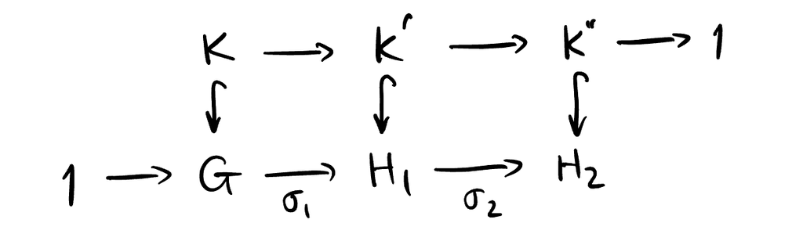

Figure 5: Commutative diagram of groups

**Proof of the third isomorphism theorem**

Figure 5 can be visually represented by this cartoon:

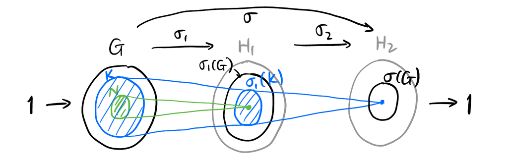

Figure 6: Visual demo of the proof of the third isomorphism theorem

by the first isomorphism theorem, we have:
$$G/N \simeq \sigma_1 (G) \triangleright \sigma_1 (K) \simeq K/N.$$
Therefore,
$$\frac{G/N}{K/N} = \frac{\sigma_1 (G)}{\sigma_1 (K)} \simeq \sigma_2 \circ \sigma_1 (G) =: \sigma (G) \simeq \frac{G}{K}.$$